# Trend Analysis of Water Quality Data in Biscayne Bay: Impacts of Summer Fertilizer Ordinance

https://github.com/jzwu01/Wu_Heinlein_RidolfiStarr

Dashiell Ridolfi-Starr & Joy Wu & Jordan Heinlein

Fall 2025

## 0.1 List of Tables

*Dataset Information*

- Table 2.1: Parameter Summary Statistics

*Analysis*

- Table 4.1: Results Summary of SMK on Pre- and Post-Ordinance Monthly Averages
- Table 4.2: Results Summary of ANOVA on Yearly Averages
- Table 4.3: Results Summary of Tukey’s HSD on Yearly Averages

## 0.2 List of Figures

*Dataset Information*

- Figure 2.1: Water Quality Parameter Readings

*Exploratory Analysis*

- Figure 3.1: Monthly Averages of Water Quality Parameters
- Figure 3.2: Distributions of Water Quality Parameter Values by Year

*Analysis*

- Figure 4.1: Comparing Pre- and Post-Ordinance Trends in Water Quality Parameters
- Figure 4.2: Parameter Yearly Averages
- Figure 4.3: Comparing Yearly Averages with Interpolated Monthly Averages: Phosphorous
- Figure 4.4: Comparing Yearly Averages with Interpolated Monthly Averages: Nitrogen
- Figure 4.5: Comparing Yearly Averages with Interpolated Monthly Averages: Dissolved Oxygen
- Figure 4.6: Comparing Yearly Averages with Interpolated Monthly Averages: pH

# 1 Rationale and Research Questions

Urban coastal ecosystems are sensitive to stormwater runoff, which is rain water and waste water that flows over streets, sidewalks, and other surfaces. It picks up debris, oil, fertilizers, and other pollutants along the way before entering the stormwater system. The system is designed to drain cities of rain water and help minimize flooding. As a result, it carries and deposits polluted runoff into surrounding waterways, causing harm to nearby ecosystems. Unfortunately, this is the case for Biscayne Bay near the City of Miami Beach. To address such issues, Miami-Dade County implemented an ordinance that prohibits the use of fertilizers containing nitrogen and phosphorus during the summer rainy season. The ordinance was passed in January, 2021, and was adopted in April of the same year. The ordinance is effective from May 15 through October 31 every year (accounting for raining season).

This study examines whether measurable changes in nutrient concentrations or related indicators appeared following the implementation of the Miami-Dade County fertilizer ordinance by using data from the City of Miami Beach Water Monitoring Program. The goal is to quantify these changes through time series and statistical analyses. We chose to look at this specific dataset because it includes measurements for multiple years, and it is specific to the location that we are looking to assess. It also measures parameters that are crucial to our analyses: total nitrogen, total phosphorus, dissolved oxygen, and pH. We chose to examine dissolved oxygen because it is indirectly related to dissolved phosphorous and nitrogen levels. Under increased phosphorous and nitrogen loads, aquatic ecosystems can undergo eutrophication and be depleted of oxygen.

Based on the background research and context, our hypothesis is that total phosphorous and total nitrogen are likely to decrease, dissovled oxygen are likely to increase, and pH are likely to stay the same.

# 2 Dataset Information

## 2.1 Raw Data

Below is the structure of the raw dataset used in this project.

```
## 'data.frame':    25836 obs. of  38 variables:
##  $ RowID                  : int  4175 4176 4177 4178 4179 4180 4181 4182 4183 4245 ...
##  $ ProgramID              : int  4058 4058 4058 4058 4058 4058 4058 4058 4058 4058 ...
##  $ ProgramName            : chr  "City of Miami Beach Water Monitoring" "City of Miami Beach Water Monitoring" "City of Miami Beach Water Monitoring" "City of Miami Beach Water Monitoring" ...
##  $ Habitat                : chr  "Water Column" "Water Column" "Water Column" "Water Column" ...
##  $ IndicatorID            : int  6 6 6 6 6 6 6 6 6 6 ...
##  $ IndicatorName          : chr  "Nutrients" "Nutrients" "Nutrients" "Nutrients" ...
##  $ ParameterID            : int  19 19 19 17 17 17 17 17 17 19 ...
##  $ ParameterName          : Factor w/ 10 levels "Dissolved_O2",..: 8 8 8 2 2 2 2 2 2 8 ...
##  $ ParameterUnits         : chr  "mg/L" "mg/L" "mg/L" "mg/L" ...
##  $ LocationID             : int  1307494 1307480 1307511 1307474 1307493 1307501 1307511 1307499 1307490 1307514 ...
##  $ ProgramLocationID      : Factor w/ 55 levels "16","17","18",..: 27 14 35 8 26 31 35 29 23 36 ...
##  $ ProgramLocationName    : chr  "40" "29" "56" "23" ...
##  $ AreaID                 : int  6 6 6 6 6 6 6 6 6 6 ...
##  $ ManagedAreaName        : chr  "Biscayne Bay Aquatic Preserve" "Biscayne Bay Aquatic Preserve" "Biscayne Bay Aquatic Preserve" "Biscayne Bay Aquatic Preserve" ...
```

[output cut: 24 more lines]

## 2.2 Data Wrangling

The imported data frame was first adjusted to include only the following columns: SampleDate, ParameterName, ResultValue, Year, Month, ProgramLocationID, OriginalLatitutude, and OriginalLongitude. Observations were then grouped by date and averaged to consolidate multiple readings occurring over a single day. Distinct parameters from the ParameterName column were then pivoted into their own columns with corresponding values from the ResultValue column. A new factor column was created to indicate whether an observation occurred before or after the April 2021 summer fertilizer ordinance.

Unprocessed observations were plotted in the figure below to identify extreme outliers. Several extreme values are evident in the dissolved oxygen and pH data.

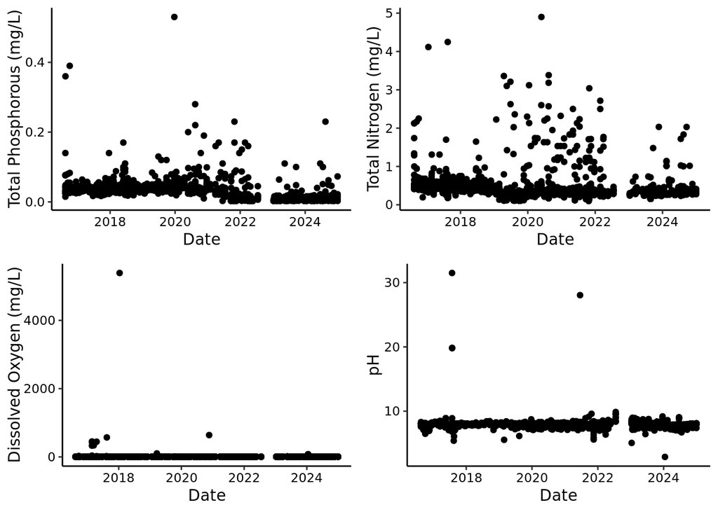

Figure 2.1: Water Quality Parameter Readings

Extreme outliers representing impossible values for Biscayne Bay (dissolved oxygen > 1000 and pH > 15) were identified visually using Figure 2.1 and replaced with NA values. The remaining data likely still contain less-extreme outliers.

For a monthly time series analysis, the daily parameter readings were grouped by month and averaged. The resulting monthly averages were joined to a continuous sequence of months spanning the timeframe of the dataset to identify missing observations in preparation for interpolation. Linear interpolation was performed before subsetting into two data frames of pre- and post-ordinance observations.

To assess yearly averages, the daily parameter readings were grouped by year and averaged.

Table 2.1: Parameter Summary Statistics

| Parameter | Units | Minimum | Maximum | Mean | Std_Deviation |
| --- | --- | --- | --- | --- | --- |
| Total Phosphorous | mg/L | 0.0028 | 0.53 | 0.030 | 0.025 |
| Total Nitrogen | mg/L | 0.1010 | 4.90 | 0.442 | 0.354 |
| Dissolved Oxygen | mg/L | 0.0100 | 640.00 | 7.463 | 28.771 |
| pH | NA | 2.8800 | 9.87 | 7.947 | 0.351 |

Descriptive statistics of the study parameters (with the most extreme outliers removed) are summarized in Table 2.1.

# 3 Exploratory Analysis

## 3.1 Geographic Context

[interactive chart not shown]

Water quality samples included in this dataset were collected within, or in waters adjacent to the Biscayne Bay, an estuary system that includes Florida state-designated aquatic preserves, and both a national park and marine sanctuary. Historically an oligotrophic (low nutrients) water body, the Bay has undergone increasing eutrophication in recent time due to a variety of factors including upland development and water management. Eutrophication is negatively impacting both the water and habitat quality of the Bay (Miami-Dade County, 2019). Miami Beach’s water quality monitoring sample locations are mainly within the Southern North Bay region of Biscayne Bay. According to the Miami-Dade County Biscayne Bay Report Card, this region has consistently received a grade of “poor”, indicating that there is “considerable water quality and/or ecological degradation” (Miami-Dade County, 2025).

## 3.2 Monthly Averages

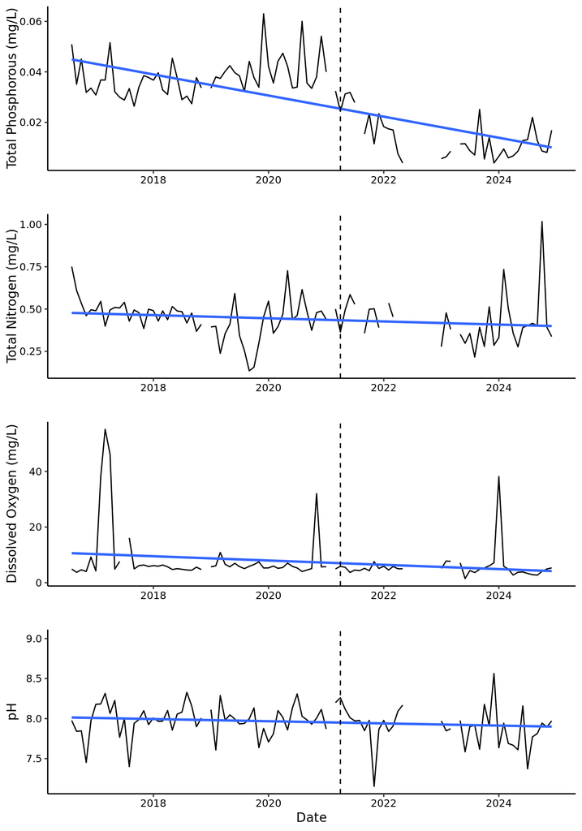

Figure 3.1: Monthly Averages of Water Quality Parameters

We began by creating line plots for each parameter, showing their average monthly concentrations through time (Figure 3.1). The vertical dotted line represents the implementation of the Miami-Dade County summer fertilizer ordinance (April, 2021). Each plot was fitted with a trend line and a vertical line indicated when the County’s fertilizer ordinance went into effect. Based on these plots, total phosphorous appears to be decreasing over the monitoring period and is the only parameter that shows a discernable trend. While total nitrogen, dissolved oxygen, and pH exhibit fluctuations in monthly values, these plots do not indicate trends in these parameters between 2016 and 2024. Plotting these values also exposed multiple data gaps in the series, with the most extensive occurring in 2022. This was an important finding with implications for time series analysis.

## 3.3 Yearly Distributions

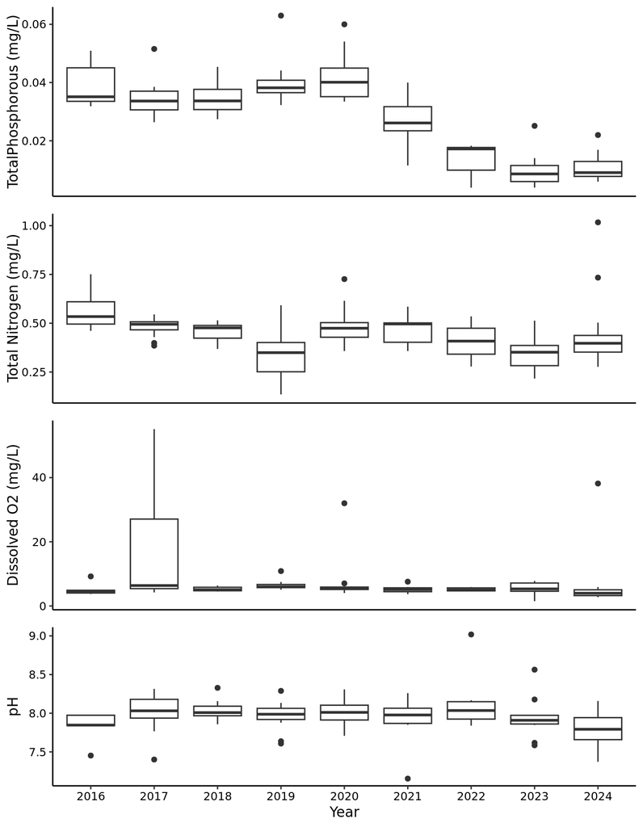

Figure 3.2: Distributions of Water Quality Parameter Values by Year

# 4 Analysis

## 4.1 Question 1: How do the pre- and post-ordinance trends in monthly averages compare in terms of A) Total Phosphorous, B) Total Nitrogen, C) Dissolved Oxygen, and D) pH?

### 4.1.1 Pre- vs. Post-Ordinance Monthly Trend Analysis

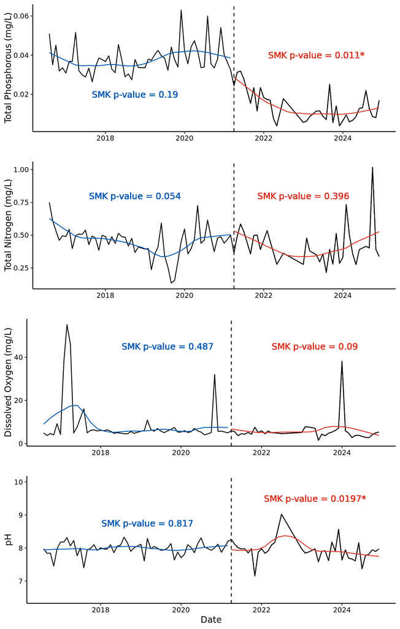

Figure 4.1: Comparing Pre- and Post-Ordinance Trends in Water Quality Parameters

We conducted a monthly time series analysis of the four study parameters to assess whether monotonic trends differed before and after the implementation of the ordinance. Blue curves represent pre-ordinance trends and red curves represent post-ordinance trends. The dashed vertical line in these plots represents implementation of the ordinance. Seasonal Mann-Kendall (SMK) tests were applied separately to pre- and post-ordinance periods to evaluate the presence of statistically significant monotonic trends while accounting for seasonality (Figure 4.1).

Table 4.1: Results Summary of SMK on Pre- and Post-Ordinance Monthly Averages

|  | Pre.Ordinance_Z.Stat | Pre.Ordinance_p.value | Post.Ordinance_Z.Stat | Post.Ordinance_p.value |
| --- | --- | --- | --- | --- |
| Total_Phosphorous | 1.312 | 0.190 | -2.544 | 0.011 |
| Total_Nitrogen | -1.929 | 0.054 | -0.848 | 0.396 |
| Dissolved_Oxygen | -0.694 | 0.487 | -1.696 | 0.090 |
| pH | 0.231 | 0.817 | -2.332 | 0.020 |

Time series analysis reveals statistically significant, downward monotonic trends in post-ordinance Total Phosphorous (SMK; z < 0, p-value < 0.05) and post-ordinance pH (SMK; z < 0, p-value < 0.05). For both parameters, no significant trend was observed prior to the ordinance implementation. For the other two parameters, total nitrogen and dissolved oxygen, plotted time series trends show some variability, but no significant monotonic trends before or after the ordinance. SMK results for all parameters are summarized in Table 4.1.

### 4.1.2 Comparison of Monthly and Yearly Trends

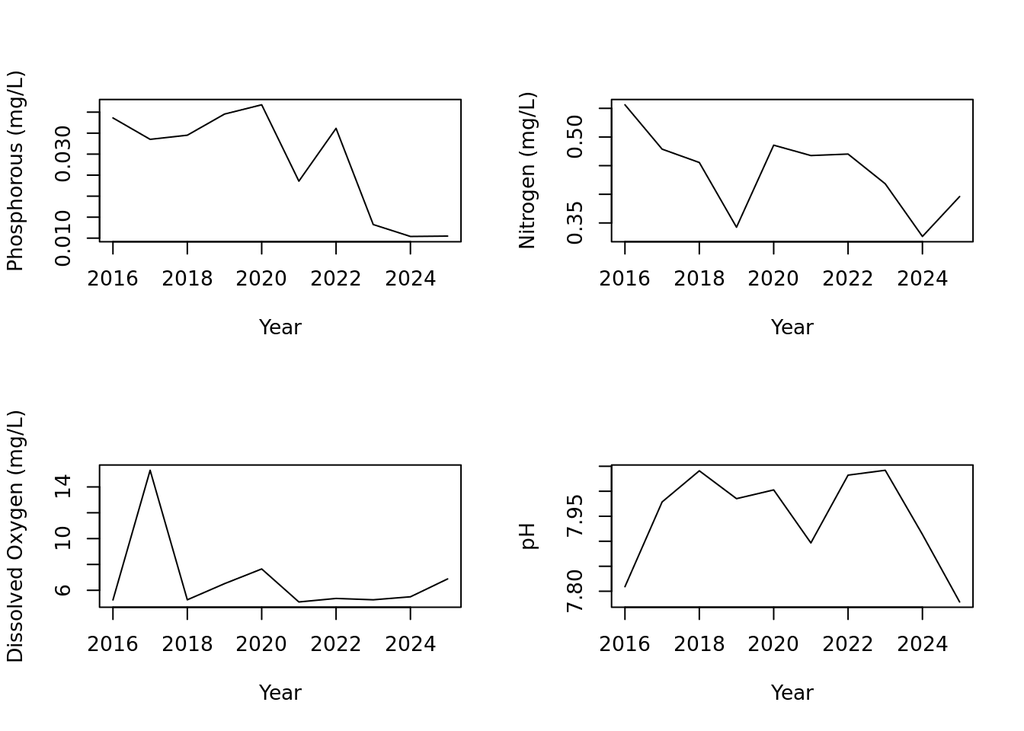

Figure 4.2: Parameter Yearly Averages

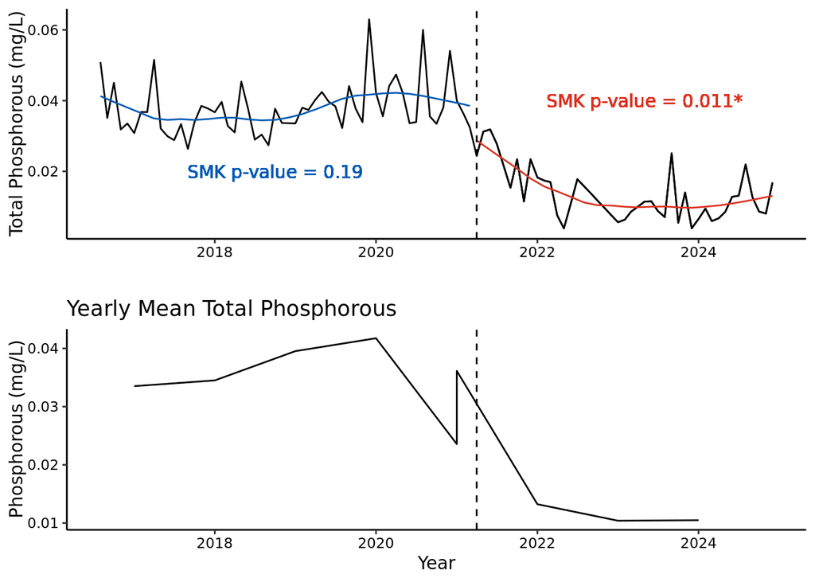

Figure 4.3: Comparing Yearly Averages with Interpolated Monthly Averages: Total Phosphorous

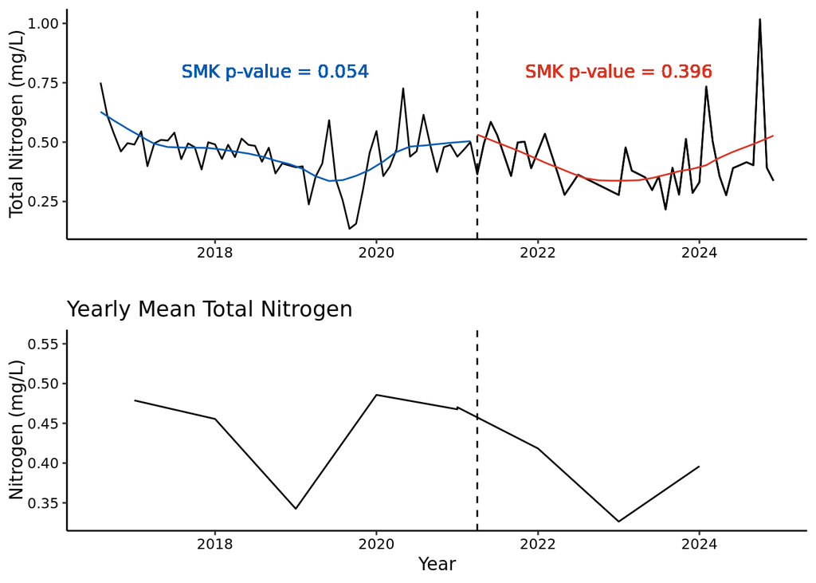

Figure 4.4: Comparing Yearly Averages with Interpolated Monthly Averages: Total Nitrogen

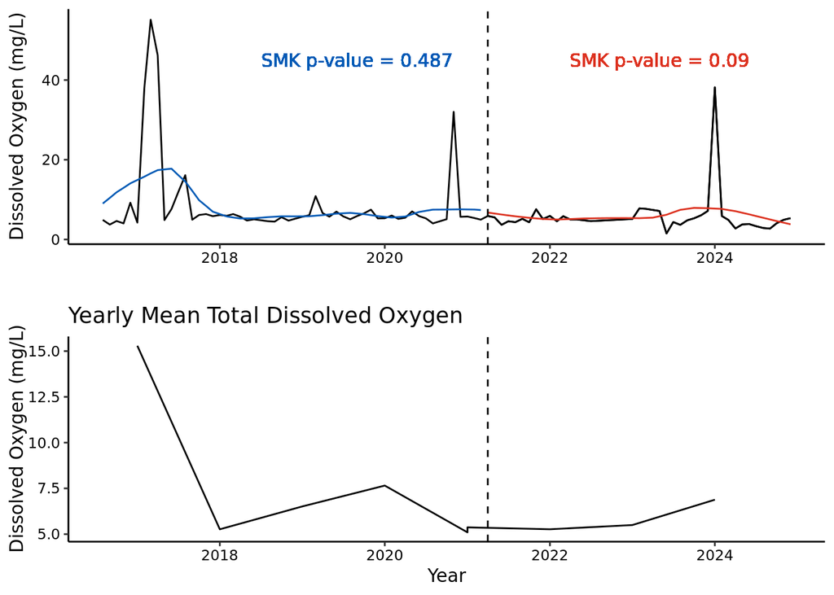

Figure 4.5: Comparing Yearly Averages with Interpolated Monthly Averages: Dissolved Oxygen

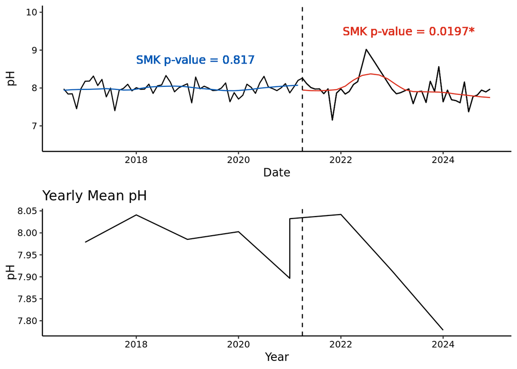

Figure 4.6: Comparing Yearly Averages with Interpolated Monthly Averages: pH

To compare the results in a more visual way, we stacked the monthly and yearly plots to assess their trends for each of the parameters (Figures 4.3, 4.4, 4.5, 4.6). For all four parameters, the monthly and yearly plots seem to follow similar trends. The yearly mean total phosphorus concentrations show a clear decline beginning in 2021, which is consistent with the significant post-ordinance monotonic trend we identified earlier in monthly analyses. The yearly mean total nitrogen presented larger variability regarding trends throughout the years, but its general trend had a declining direction after 2021. The yearly mean dissolved oxygen had large spikes during the early times and showed limited differentiation after ordinance implementation, while the yearly mean pH showed a modest decline following 2021.

The similar plot patterns between the monthly and yearly time series suggest that the observed post-ordinance declines in phosphorous and pH are consistent across time scales, while nitrogen and dissolved oxygen show high variability in both datasets.

## 4.2 Question 2: Are there significant differences among the yearly averages for A) Total Phosphorous, B) Total Nitrogen, C) Dissolved Oxygen, and D) pH?

### 4.2.1 ANOVA on Yearly Means

Table 4.2: Results Summary of ANOVA on Yearly Averages

|  | Parameter | Df | Sum Sq | Mean Sq | F value | Pr(>F) |
| --- | --- | --- | --- | --- | --- | --- |
| Year …1 | Total_Phosphorous | 8 | 0.014 | 0.002 | 36.184 | 0.00000 |
| Residuals …2 | Total_Phosphorous | 82 | 0.004 | 0.000 | NA | NA |
| Year …3 | Total_Nitrogen | 8 | 0.374 | 0.047 | 3.554 | 0.00143 |
| Residuals …4 | Total_Nitrogen | 80 | 1.052 | 0.013 | NA | NA |
| Year …5 | Dissolved_O2 | 8 | 1392.017 | 174.002 | 2.605 | 0.01368 |
| Residuals …6 | Dissolved_O2 | 82 | 5477.033 | 66.793 | NA | NA |
| Year …7 | pH | 8 | 0.835 | 0.104 | 1.859 | 0.07768 |
| Residuals …8 | pH | 83 | 4.661 | 0.056 | NA | NA |

One-way analysis of variance (ANOVA) was performed on the four study parameters using year as a categorical variable to calculate means (without interpolation). Analysis of total phosphorous (df = 8, F = 36.18, p < 0.00001), total nitrogen (df = 8, F = 3.554, p < 0.005), and dissolved oxygen (df = 8, F = 2.61, p < 0.05) found statistically significant differences among the yearly means. There were no statistically significant differences among yearly means for pH (df = 8, F = 1.86, p = 0.078). These results indicate that there are relatively stronger shifts between years in average total phosphorous, total nitrogen, and dissolved oxygen compared to pH.

### 4.2.2 Tukey’s HSD

Table 4.3: Results Summary of Tukey’s HSD on Yearly Averages

| Year | Phosphorous_Mean | P_Group | Nitrogen_Mean | N_Group | Diss_O2_Mean | O2_Group |
| --- | --- | --- | --- | --- | --- | --- |
| 2016 | 0.039 | a | 0.570 | a | 5.301 | b |
| 2017 | 0.035 | ab | 0.481 | abc | 17.773 | a |
| 2018 | 0.035 | ab | 0.455 | abc | 5.286 | b |
| 2019 | 0.040 | a | 0.336 | c | 6.500 | b |
| 2020 | 0.042 | a | 0.487 | ab | 7.623 | ab |
| 2021 | 0.026 | b | 0.466 | abc | 5.173 | b |
| 2022 | 0.014 | c | 0.407 | abc | 5.151 | b |
| 2023 | 0.010 | c | 0.348 | bc | 5.510 | b |
| 2024 | 0.011 | c | 0.463 | abc | 6.883 | b |

Following ANOVA, Tukey’s honestly significant difference test (HSD) was used to identify years with diverging means across variables. The pH parameter was omitted from this test to avoid type I error, since ANOVA failed to produce a statistically significant result. HSD results are summarized in Table 4.3.

Yearly total phosphorous means are more uniquely identified, with seven years belonging to single mean groups. Among these years, the highest statistically unique mean group (a) occurs only before 2021, an intermediate one (b) occurs during 2021, and the lowest (c) occurs only afterward. This provides strong evidence that phosphorous levels started decreasing in 2021.

Total nitrogen also showed statistically distinct mean groups, but with no discernible relationship to implementation of the ordinance. Both the highest and lowest mean groups (a, c) occurred alone only before the ordinance. Significant differences in average nitrogen levels is likely due to external factors.

Dissolved oxygen has one uniquely high mean group (a) that occurred in 2017. This result indicates an anomalous average in 2017, not a trend over time.

With the exception of the anomalous dissolved oxygen average, these results suggest that nutrient levels show greater fluctuation across years than the physical water quality parameters examined.

# 5 Summary and Conclusions

## 5.1 Total Phosphorous

Our results provide strong evidence that total phosphorous levels in Biscayne Bay fell significantly after the summer fertilizer ordinance. While there is no trend over time in the pre-ordinance data, a strong downward trend emerges in the post-ordinance data. Significantly lower yearly means also emerge after the ordinance. This suggests that implementation of the ordinance led to a measurable decrease in dissolved phosphorous concentrations in Biscayne Bay.

## 5.2 Total Nitrogen

Our findings indicated that total nitrogen did not appear to be affected by the ordinance implementation. Both time series trends and ANOVA failed to produce statistically significant results aligning with the ordinance. Nitrogen is a primary ingredient in most fertilizers and would be expected to decrease with less fertilizer use. However, there are many other sources of nitrogen pollution and environmental factors that can influence measurements. More specific analysis, perhaps focusing on nitrogen forms common in fertilizers, such as nitrates, may be more informative.

## 5.4 pH

Our data produced mixed results that may suggest a decline in pH after the ordinance was implemented. The post-ordinance downward trend over time was statically significant, but this was the only such result; ANOVA found no significantly different means. Interestingly, interpolation of monthly averages produced a notable upward spike in pH after the ordinance, and the SMK still identified a downward trend. These results suggest a slight trend that may be too fine to appear in coarse, yearly averages.

## 5.5 Conclusion

Overall, this analysis was challenged by data availability. Missing observations from 2022 required interpolation of a large data gap. Analysis at the yearly level was too coarse to detect pre- and post-ordinance trends. Still, one strong trend emerged as phosphorous clearly began to decline after the ordinance.

Other results paint an ambiguous picture of water quality following the fertilizer ordinance. Nitrogen levels and pH may have also started to decrease after the ordinance, having shown significance in one statistical test but not another. It is possible that these results were influenced by external factors like precipitation, so these findings should be confirmed by further analysis. Dissolved oxygen levels showed no signs of change.

Declining phosphorous and nitrogen levels represent a positive scenario for marine life, as excess dissolved nutrients can lead to eutrophication and other ecosystem disruptions. Falling pH is not strictly positive, as it mirrors a global trend of dangerous ocean acidification due to high atmospheric carbon dioxide levels. Our analysis suggests that the county ordinance may be having a positive impact on water quality, but also highlights the need for additional improvement measures and continued, consistent data collection.

# 6 References

1. City of Miami Beach. (2024). City of Miami Beach Water Monitoring. Updated 04/09/2025. Distributed by: SEACAR Data Discovery Interface, Office of Resilience and Coastal Protection, Florida Department of Environmental Protection. https://data.florida-seacar.org/programs/details/4058
2. Eutrophication: https://www.usgs.gov/mission-areas/water-resources/science/nutrients-and-eutrophication
3. Ocean acidification: https://www.noaa.gov/education/resource-collections/ocean-coasts/ocean-acidification
4. On dissolved oxygen: https://waterwatch.ifas.ufl.edu/media/waterwatchifasufledu/DO-Nutrients-double-sided.pdf
5. Ordinance (county): https://library.municode.com/fl/miami_-_dade_county/codes/code_of_ordinances?nodeId=PTIIICOOR_CH18CMIDECOORFLIEFEUSURLA
6. 2019 Biscayne Bay Report Card. Miami-Dade County: https://documents.miamidade.gov/mayor/memos/12.10.20-Health-of-Biscayne-Bay%E2%80%93Report-Card-Program.pdf
7. 2025 Biscayne Bay Report Card. Miami-Dade County: https://experience.arcgis.com/experience/02ea7212988b4d6c856279503d991e01